# Clustering with K-means

STOR 390

# Outline

- unsupervised vs. supervised learning
- clustering
- K-means

# Unsupervised learning

> Unsupervised machine learning is the machine learning task of inferring a function to describe hidden structure from “unlabeled” data.

# Supervised learning

> Supervised learning is the machine learning task of inferring a function from labeled training data.

# Examples

- supervised
  - regression (e.g. linear model)
  - classification (e.g. KNN)
- unsupervised
  - clustering (e.g. K-means)
  - dimensionality reduction (e.g. PCA)

# Unsupervised learning: find a meaningful pattern

- what does “meaningful” mean?

# Clustering

- Goal: automatically find meaningful subgroups in the data

# Two dimensional example (raw data)

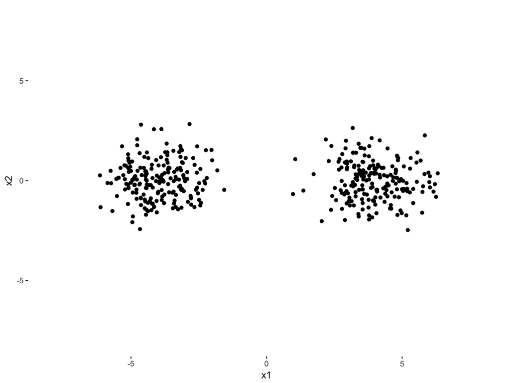

# Two dimensional example (after clustering)

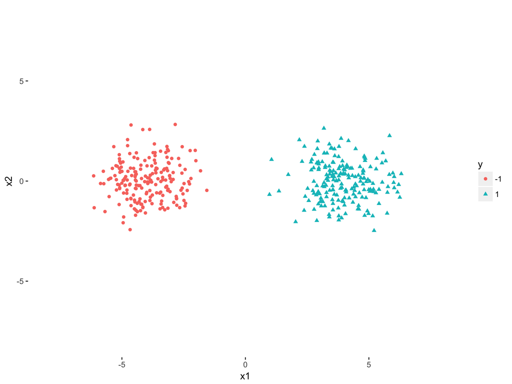

# K-means

- simple clustering algorithm
  - similar go nearest centroid
- user picks K

# K-means algorithm

1. Randomly assign a number, from 1 to K, to each of the observations. These serve as initial cluster assignments for the observations.
2. Iterate until the cluster assignments stop changing:
   1. For each of the K clusters, compute the cluster centroid.
   2. Assign each observation to the cluster whose centroid is closest.

# Raw data

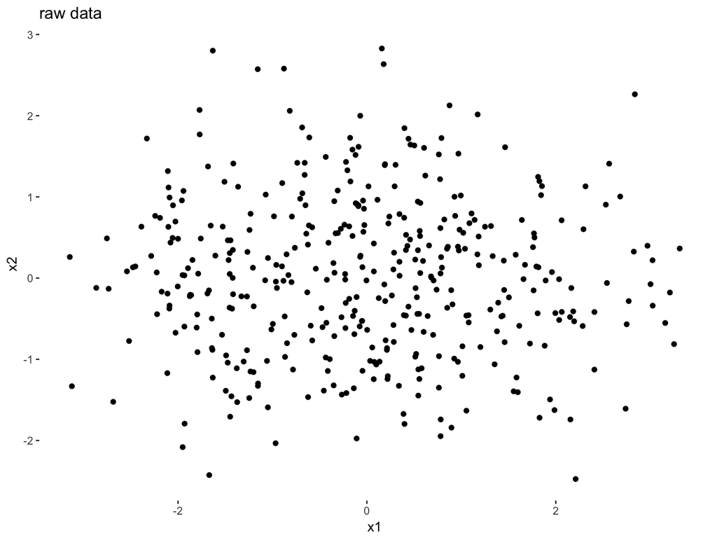

# Random initialization

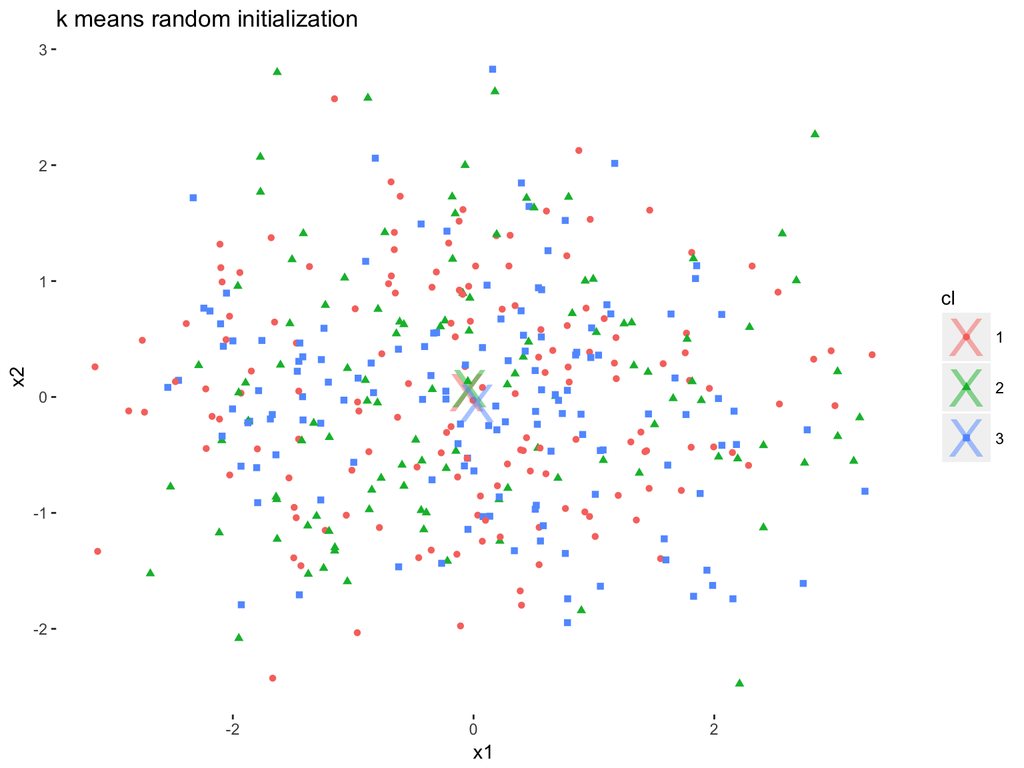